# R Notebook

#2.1 Question 1 We are going to use a dataset on house sales in Ames, Iowa over a number of years. We will be interested in the SalePrice of houses (though we should clean_names() the data, so this will end up as sale_price). Load the data and explore it.

```r
ames <- read_csv("data/ames.csv") %>%
  janitor::clean_names()
```

[output not shown]

```r
ames
```

| order | pid | ms_sub_class | ms_zoning | lot_frontage | lot_area | street | alley | lot_shape | land_contour | utilities | lot_config | land_slope | neighborhood | condition_1 | condition_2 | bldg_type | house_style | overall_qual | overall_cond | year_built | year_remod_add | roof_style | roof_matl | exterior_1st | exterior_2nd | mas_vnr_type | mas_vnr_area | exter_qual | exter_cond | … |
| --- | --- | --- | --- | --- | --- | --- | --- | --- | --- | --- | --- | --- | --- | --- | --- | --- | --- | --- | --- | --- | --- | --- | --- | --- | --- | --- | --- | --- | --- | --- |
| 1 | 526301100 | 20 | RL | 141 | 31770 | Pave | NA | IR1 | Lvl | AllPub | Corner | Gtl | NAmes | Norm | Norm | 1Fam | 1Story | 6 | 5 | 1960 | 1960 | Hip | CompShg | BrkFace | Plywood | Stone | 112 | TA | TA | … |
| 2 | 526350040 | 20 | RH | 80 | 11622 | Pave | NA | Reg | Lvl | AllPub | Inside | Gtl | NAmes | Feedr | Norm | 1Fam | 1Story | 5 | 6 | 1961 | 1961 | Gable | CompShg | VinylSd | VinylSd | None | 0 | TA | TA | … |
| 3 | 526351010 | 20 | RL | 81 | 14267 | Pave | NA | IR1 | Lvl | AllPub | Corner | Gtl | NAmes | Norm | Norm | 1Fam | 1Story | 6 | 6 | 1958 | 1958 | Hip | CompShg | Wd Sdng | Wd Sdng | BrkFace | 108 | TA | TA | … |
| 4 | 526353030 | 20 | RL | 93 | 11160 | Pave | NA | Reg | Lvl | AllPub | Corner | Gtl | NAmes | Norm | Norm | 1Fam | 1Story | 7 | 5 | 1968 | 1968 | Hip | CompShg | BrkFace | BrkFace | None | 0 | Gd | TA | … |
| 5 | 527105010 | 60 | RL | 74 | 13830 | Pave | NA | IR1 | Lvl | AllPub | Inside | Gtl | Gilbert | Norm | Norm | 1Fam | 2Story | 5 | 5 | 1997 | 1998 | Gable | CompShg | VinylSd | VinylSd | None | 0 | TA | TA | … |
| 6 | 527105030 | 60 | RL | 78 | 9978 | Pave | NA | IR1 | Lvl | AllPub | Inside | Gtl | Gilbert | Norm | Norm | 1Fam | 2Story | 6 | 6 | 1998 | 1998 | Gable | CompShg | VinylSd | VinylSd | BrkFace | 20 | TA | TA | … |
| 7 | 527127150 | 120 | RL | 41 | 4920 | Pave | NA | Reg | Lvl | AllPub | Inside | Gtl | StoneBr | Norm | Norm | TwnhsE | 1Story | 8 | 5 | 2001 | 2001 | Gable | CompShg | CemntBd | CmentBd | None | 0 | Gd | TA | … |
| 8 | 527145080 | 120 | RL | 43 | 5005 | Pave | NA | IR1 | HLS | AllPub | Inside | Gtl | StoneBr | Norm | Norm | TwnhsE | 1Story | 8 | 5 | 1992 | 1992 | Gable | CompShg | HdBoard | HdBoard | None | 0 | Gd | TA | … |
| 9 | 527146030 | 120 | RL | 39 | 5389 | Pave | NA | IR1 | Lvl | AllPub | Inside | Gtl | StoneBr | Norm | Norm | TwnhsE | 1Story | 8 | 5 | 1995 | 1996 | Gable | CompShg | CemntBd | CmentBd | None | 0 | Gd | TA | … |
| 10 | 527162130 | 60 | RL | 60 | 7500 | Pave | NA | Reg | Lvl | AllPub | Inside | Gtl | Gilbert | Norm | Norm | 1Fam | 2Story | 7 | 5 | 1999 | 1999 | Gable | CompShg | VinylSd | VinylSd | None | 0 | TA | TA | … |

[output cut: 990 more lines]

```r
NA
```

#2.2 Question 2 Plot a histogram of sale_price. Is the distribution normal?

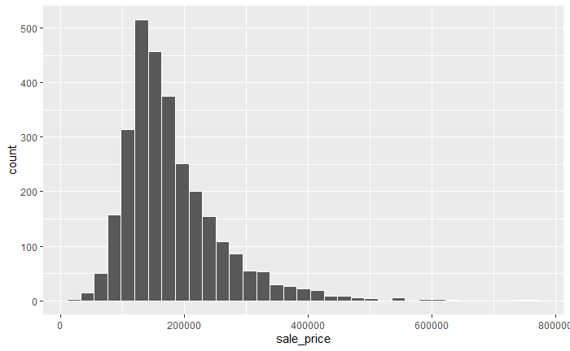

```r
options(scipen = 999)
ames %>%
  ggplot()+
  aes(x = sale_price)+
  geom_histogram(col = "white",bins = 35)
```

#2.3 Question 3 #Calculate the population parameter mean of sale_price. Store it in a variable, as we’ll need this value later when we check if each CI contains the parameter value or not.

| mean_sale_price |
| --- |
| 180796.1 |

#Use the infer workflow to generate the bootstrap distributions and CIs. This code will be pretty hard to write. Think about wrapping the sample creation and infer code in a for loop to generate 1000 random samples and CIs. Create an empty results tibble before the loop, and bind_rows() to it every time you generate a new set of CI bounds.

| sample_num | lower | upper |
| --- | --- | --- |
| 1 | 171959.5 | 198538.8 |
| 2 | 163040.0 | 193732.4 |
| 3 | 159815.8 | 186858.7 |
| 4 | 162870.6 | 189488.8 |
| 5 | 163257.7 | 191903.9 |
| 6 | 162408.7 | 188458.5 |
| 7 | 158388.6 | 189118.1 |
| 8 | 171434.0 | 204349.8 |
| 9 | 159776.8 | 198314.6 |
| 10 | 156342.4 | 183228.9 |

[output cut: 311 more lines]

# Question 5

#Pipe results to mutate() to add a new variable popn_param_in_ci which will be TRUE if the population parameter we calculated earlier is between lower and upper, and FALSE otherwise.

#[Hint if you stored your parameter in a tibble earlier (e.g. as the result of a summarise() pipe), extract it here as a numeric before you compare with upper and lower]

| sample_num | lower | upper | popn_param_in_ci |
| --- | --- | --- | --- |
| 1 | 171959.5 | 198538.8 | TRUE |
| 2 | 163040.0 | 193732.4 | TRUE |
| 3 | 159815.8 | 186858.7 | TRUE |
| 4 | 162870.6 | 189488.8 | TRUE |
| 5 | 163257.7 | 191903.9 | TRUE |
| 6 | 162408.7 | 188458.5 | TRUE |
| 7 | 158388.6 | 189118.1 | TRUE |
| 8 | 171434.0 | 204349.8 | TRUE |
| 9 | 159776.8 | 198314.6 | TRUE |
| 10 | 156342.4 | 183228.9 | TRUE |

[output cut: 311 more lines]

| sample_num | lower | upper | popn_param_in_ci |
| --- | --- | --- | --- |
| 11 | 153239.0 | 174929.2 | FALSE |
| 17 | 156286.7 | 179992.2 | FALSE |
| 39 | 184006.1 | 218160.4 | FALSE |
| 47 | 152838.8 | 179257.2 | FALSE |
| 72 | 156451.5 | 179797.7 | FALSE |
| 76 | 152791.6 | 179689.5 | FALSE |
| 77 | 182511.5 | 216078.1 | FALSE |
| 79 | 184325.0 | 214779.6 | FALSE |
| 80 | 182640.1 | 215510.4 | FALSE |
| 104 | 185998.8 | 221976.3 | FALSE |

[output cut: 17 more lines]

#2.6 Question 6 #Perform an appropriate summarise() to determine the proportion of CIs that contain the population parameter. Our confidence level was 95% (equivalent to a proportion of 0.95). Is your proportion close to that value?

| prop |
| --- |
| 0.9158879 |

#2.7 Question 7 #Have a think about what all this means, make a list of any points you don’t understand. - Imagine you had only a single 100-observation sample of the ames data (say from a 100 house survey). - Would you know ahead of time whether the CI for mean(sale_price) from your particular sample contains the correct population parameter or not?